# Sistemas y Señales Biomédicos

Ingeniería Biomédica

Ph.D. Pablo Eduardo Caicedo Rodríguez

2026-09-27

# Sistemas y Señales Biomedicos - SYSB

## What is a signal?

- A signal is a function that conveys information by mapping an independent variable (or variables) to measurable quantities.
- Formally, a signal is a mapping $x:\ \mathcal{T}\rightarrow\mathcal{A}$, where $\mathcal{T}$ is the domain (e.g., time $t\in\mathbb{R}$ or sample index $n\in\mathbb{Z}$) and $\mathcal{A}$ is the codomain (e.g., amplitudes in $\mathbb{R}$ or $\mathbb{C}$, vectors, or matrices).

## Signal Classification

[interactive chart not shown]

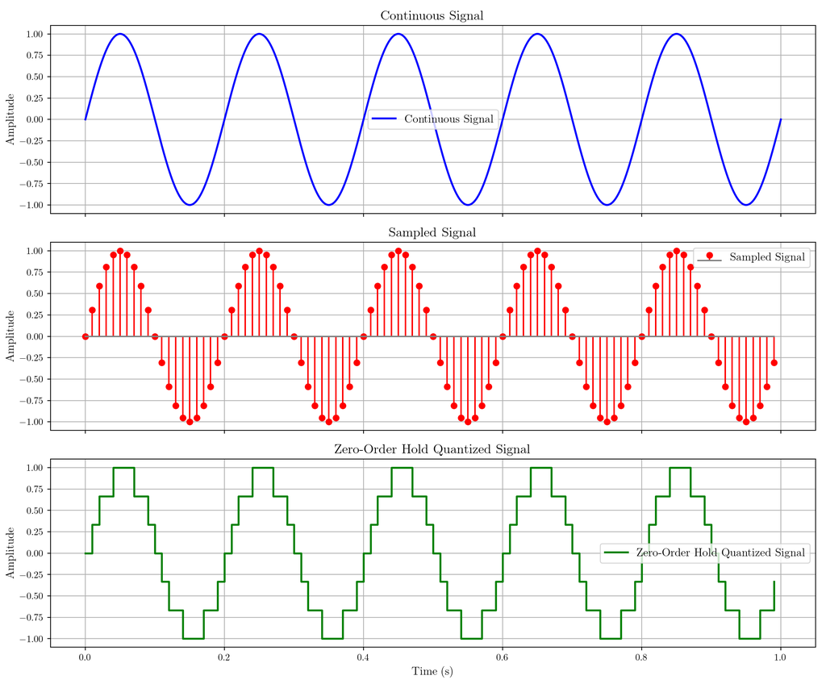

## Signal Classification – Bounded

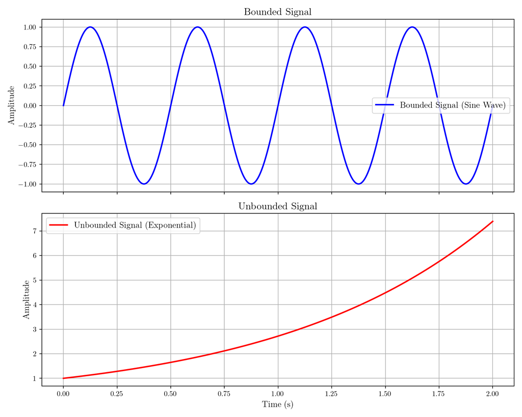

## Signal Classification – Compact Support

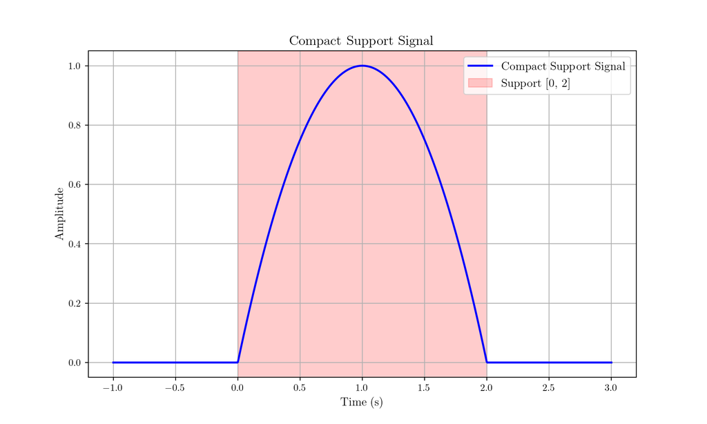

## Signal Classification – Causal

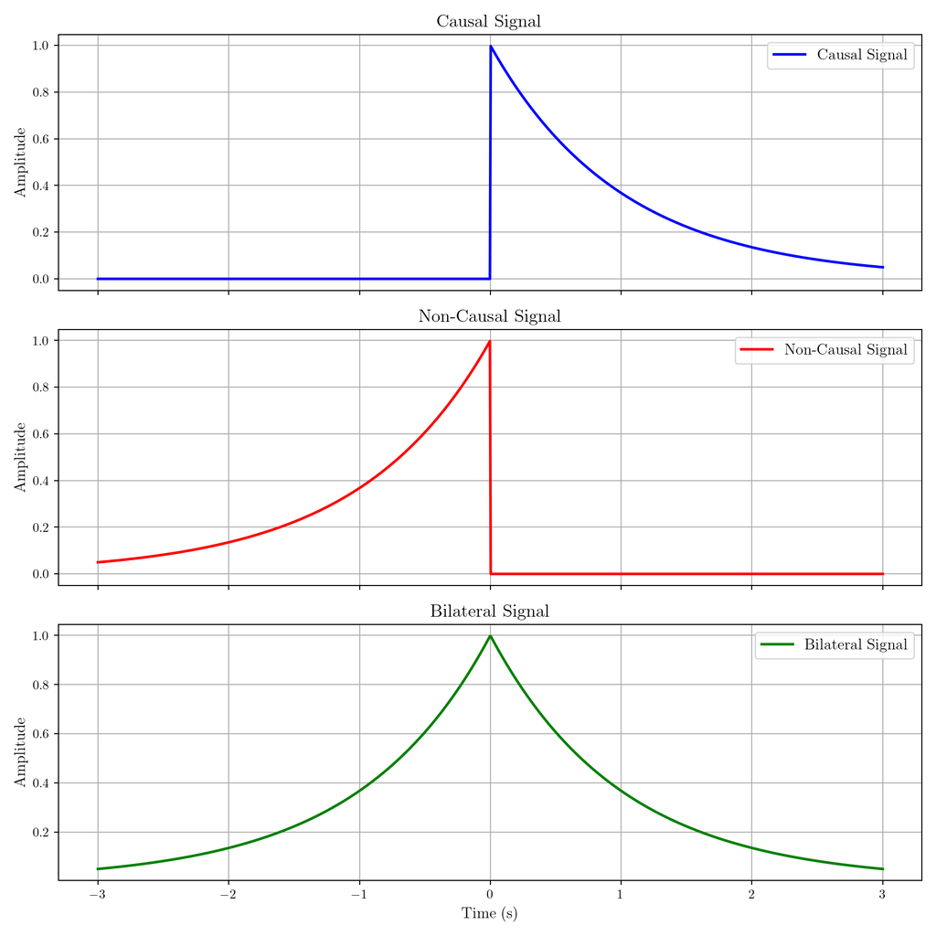

## Signal Classification - Deterministic vs Random Signals

- A deterministic signal $x_d(t)$ is completely specified by an explicit rule; it produces the same waveform on every observation (e.g., $x_d(t)=A\cos(2\pi f_0 t+\phi)$).
- A random signal (stochastic process) $X(t)$ is a family of random variables indexed by $t$; each observation yields a different realization. It is characterized statistically by its mean $\mu_X(t)$ and autocorrelation $R_X(\tau)$.

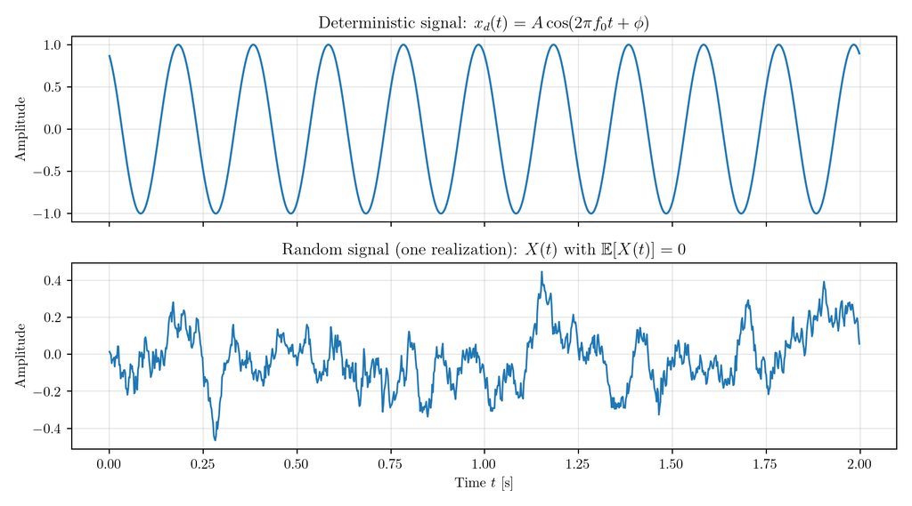

## Signal Classification - Even/Odd

**Even**

$$f\left(t\right) = f\left(-t\right)$$
$$f\left[t\right] = f\left[-t\right]$$

**Odd**

$$f\left(t\right) = -f\left(-t\right)$$
$$f\left[t\right] = -f\left[-t\right]$$

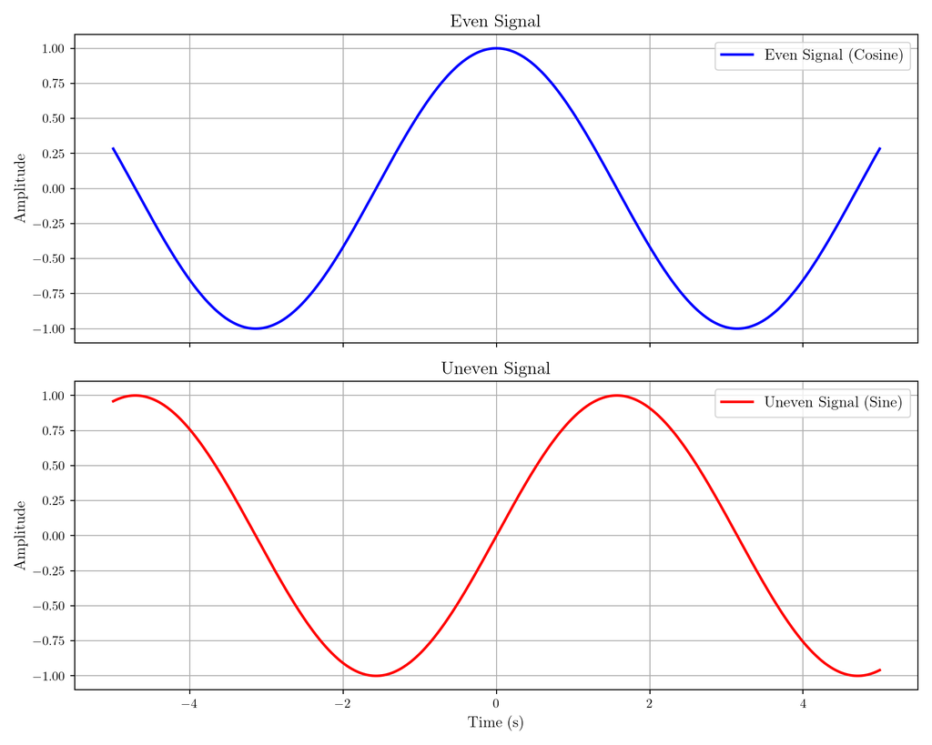

## Signal Classification

**Decomposition**

All signal can be decomposed in two signals: one even, one odd.

$$x(t) = x_{even}(t) + x_{odd}(t)$$

Where:

$$x_{even}(t) = \frac{x(t)+x(-t)}{2}$$
$$x_{odd}(t) = \frac{x(t)-x(-t)}{2}$$

## Example

**Example**

Decompose the signal $x(t)=e^{t}$ into its even and odd parts

## Example

$$x_{\text{even}}(t) = \frac{x(t) + x(-t)}{2}$$

$$x_{\text{odd}}(t) = \frac{x(t) - x(-t)}{2}$$

$$x(-t) = e^{-t}$$

$$x_{\text{even}}(t) = \frac{e^t + e^{-t}}{2} = \cosh(t)$$

$$x_{\text{odd}}(t) = \frac{e^t - e^{-t}}{2} = \sinh(t)$$

$$x(t) = x_{\text{even}}(t) + x_{\text{odd}}(t)$$

$$e^t = \cosh(t) + \sinh(t)$$

## Example

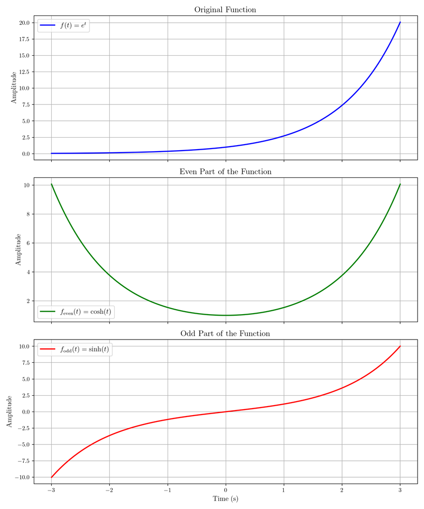

## Signal Classification - Energy vs Power Signals

Definitions. For a signal $x(t)$ (continuous-time, CT) or $x[n]$ (discrete-time, DT):

- Energy: $E=\int_{-\infty}^{\infty}\lvert x(t)\rvert^2,dt$ (CT), $\quad E=\sum_{n=-\infty}^{\infty}\lvert x[n]\rvert^2$ (DT).
- Average power: $P=\lim_{T\to\infty}\dfrac{1}{2T}\int_{-T}^{T}\lvert x(t)\rvert^2,dt$ (CT), $\quad P=\lim_{N\to\infty}\dfrac{1}{2N+1}\sum_{n=-N}^{N}\lvert x[n]\rvert^2$ (DT).
- Energy signal: $0<E<\infty$ and $P=0$ (e.g., $x_E(t)=e^{-a t}u(t)$, $a>0$, with $E=\tfrac{1}{2a}$).
- Power signal: $0<P<\infty$ and $E=\infty$ (e.g., $x_P(t)=\cos(2\pi f_0 t)$, with $P=\tfrac{1}{2}$).

## Fundamental Definitions

In signal processing, the classification of a signal $x(t)$ depends on its behavior over an infinite time interval.

**Total Energy ($E$)**
$$E = \int_{-\infty}^{\infty} |x(t)|^2 dt$$

$$E=\sum_{n=-\infty}^{\infty}\lvert x[n]\rvert^2$$

**Average Power ($P$)**
$$P = \lim_{T \to \infty} \frac{1}{2T} \int_{-T}^{T} |x(t)|^2 dt$$

$$\quad P=\lim_{N\to\infty}\dfrac{1}{2N+1}\sum_{n=-N}^{N}\lvert x[n]\rvert^2$$

## Energy Signals

A signal is classified as an **energy signal** if and only if:
$$0 < E < \infty$$
This condition implies that the average power $P = 0$.

- Typically non-periodic.
- Finite duration or rapidly decaying.

## Example: Exponential Decay

Consider the signal $x(t) = e^{-at} u(t)$ where $a > 0$.

**Proof of Energy:**
$$E = \int_{0}^{\infty} (e^{-at})^2 dt = \int_{0}^{\infty} e^{-2at} dt$$

Evaluating the definite integral:
$$E = \left[ \frac{e^{-2at}}{-2a} \right]_{0}^{\infty} = 0 - \left( \frac{1}{-2a} \right) = \frac{1}{2a}$$

**Conclusion:** Since $E$ is a finite value, it is an energy signal.

## Power Signals

A signal is classified as a **power signal** if and only if:
$$0 < P < \infty$$
This condition implies that the total energy $E = \infty$.

- Typically periodic.
- Infinite duration without decay.

## Example: Sinusoidal Signal

Consider $x(t) = A \cos(\omega_0 t)$.

**Proof of Power:** Using the period $T = \frac{2\pi}{\omega_0}$:
$$P = \frac{1}{T} \int_{0}^{T} |A \cos(\omega_0 t)|^2 dt = \frac{A^2}{T} \int_{0}^{T} \frac{1 + \cos(2\omega_0 t)}{2} dt$$

The integral of the oscillating term over a full period is zero:
$$P = \frac{A^2}{2T} [t]_0^T = \frac{A^2}{2}$$

**Conclusion:** Power is finite ($P = A^2/2$), thus it is a power signal.

## Summary Table

| Signal Type | Energy ($E$) | Power ($P$) | Characteristics |
| --- | --- | --- | --- |
| **Energy** | $0 < E < \infty$ | $P = 0$ | Aperiodic, transient |
| **Power** | $E = \infty$ | $0 < P < \infty$ | Periodic, stationary |
| **Neither** | $E = \infty$ | $P = \infty$ | e.g., $x(t) = t$ |

## Python Example

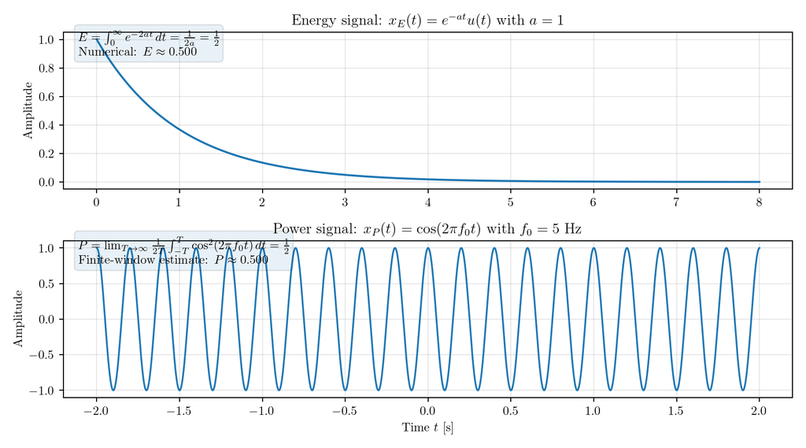

## Signal Transformations

### Types of Transformations

Signals can undergo two types of transformations:

1. **Independent variable transformations** (affect the time or input axis).
2. **Dependent variable transformations** (affect the amplitude or output axis).

## Independent Variable Transformations

### Time Shifting

- Definition: Shifts the signal in time. [ x(t - t_0) ]
- Example: ( x(t - 2) ) shifts the signal 2 units to the right.

### Time Reversal

- Definition: Flips the signal across the vertical axis. [ x(-t) ]
- Example: If ( x(t) = t^2 ), then ( x(-t) = t^2 ) (even signal).

## Combined Transformations

### Example

Consider: [ y(t) = 2 x(3t - 1) + 1 ] 1. **Time compression**: ( x(3t) ) compresses the signal. 2. **Time shift**: ( x(3t - 1) ) shifts it to the right by 1 unit. 3. **Amplitude scaling**: ( 2 x(3t - 1) ) amplifies the signal. 4. **Amplitude shift**: ( +1 ) shifts it upward.

## Visualization Example in Python

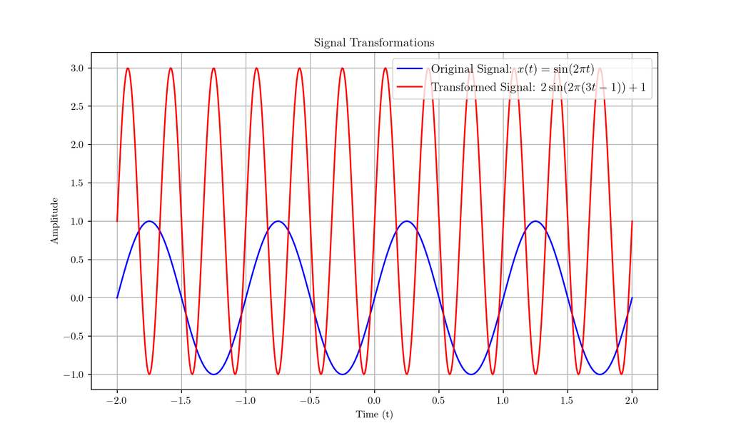